# Anàlisi de la cohort de OV utilitzant informació de MCN

## Preparació de les dades per a l’anàlisi

El fitxer de dades amb informació de l’estat WGD (Bielski) conté 338 casos de la cohort de OV.

Tenim 379 fitxers de recomptes de la cohort de OV.

L’anàlisi inclourà 214 mostres, 79 mostres sense WGD i 135 mostres amb WGD. Un 63% de les mostres de l’anàlisi han patit WGD.

## Pre-processament de les dades

Per a la filtració s’ha utilitzat un llindar de CPM de 0.08 i s’han filtrat 35676 gens, és a dir un 59% dels gens que teníem inicialment.

El rang de valors dels factors de normalització és de 0.7175311, 1.3768398.

## Exploració de les dades

### Gràfics de densitat

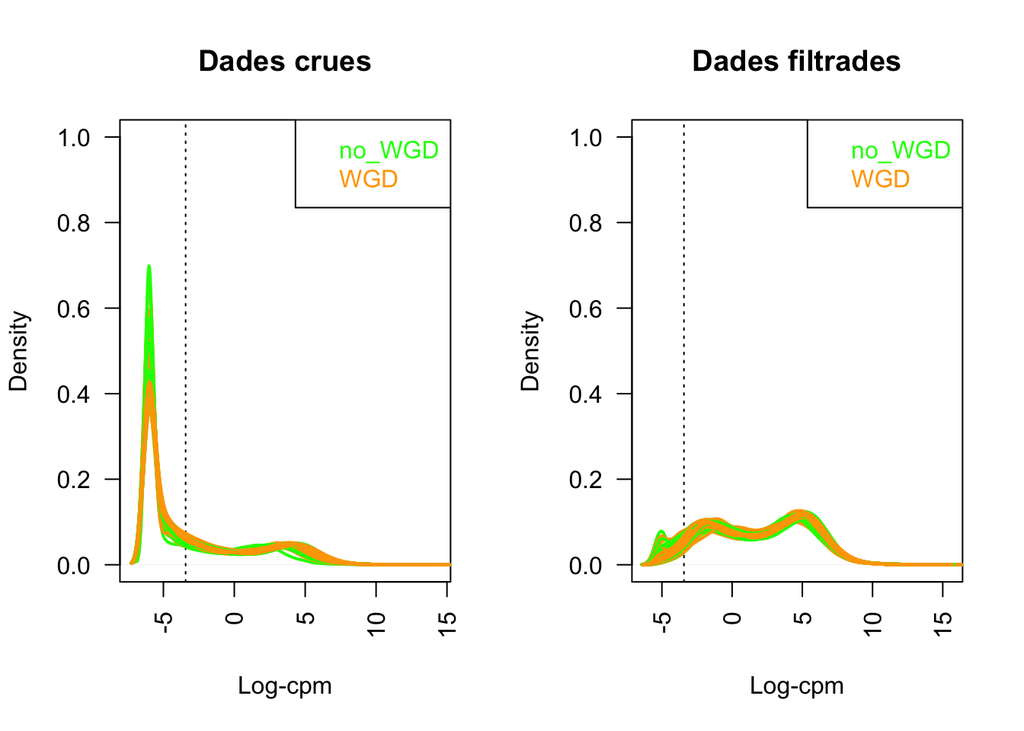

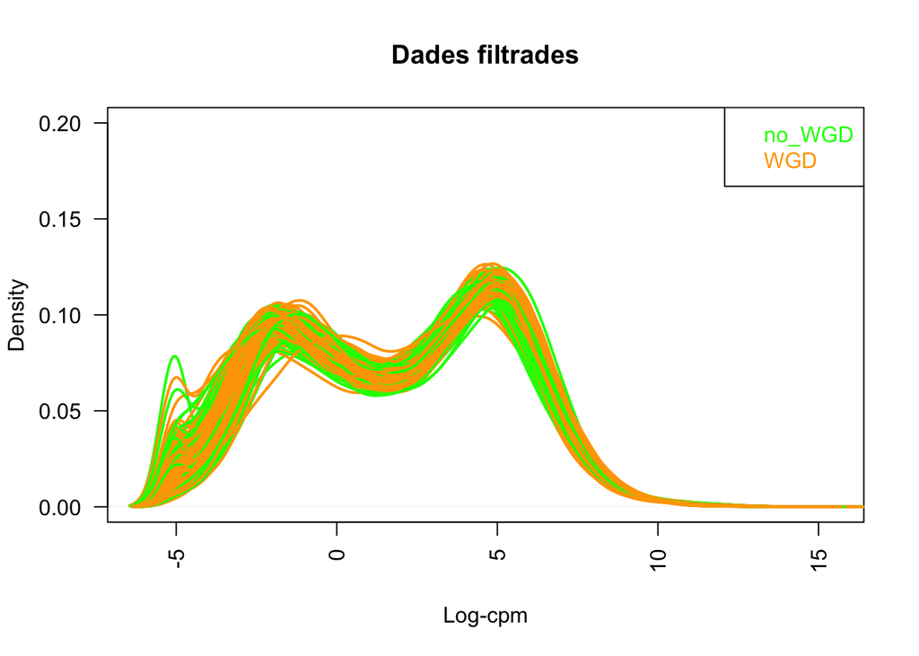

### Gràfic d’escalat multidimensional

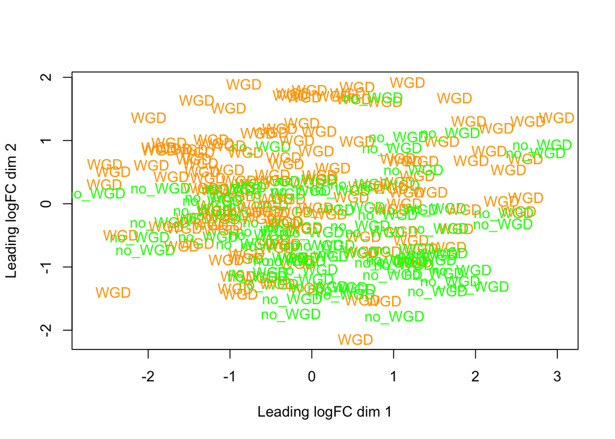

### Heatmap del gens més variables

Matriu de distàncies dels logCPM dels gens més variables. En aquest cas extraiem els 500 gens més variables a partir de les dades filtrades i normalitzades.

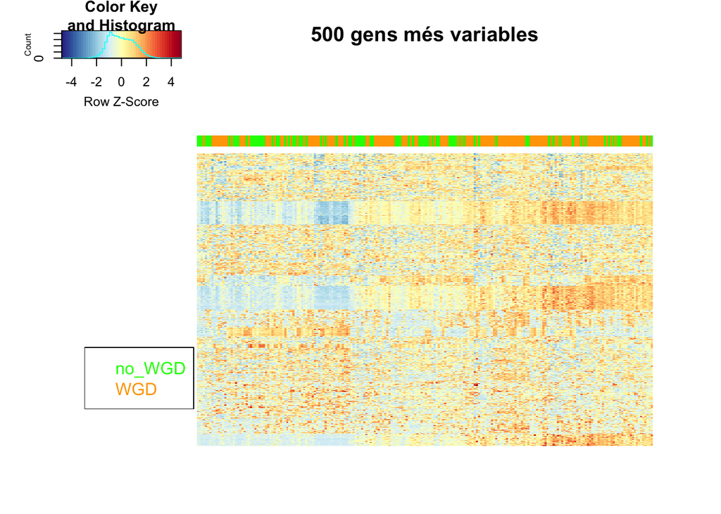

## Resultats de l’anàlisi d’expressió diferencial

### Nombre de gens diferencialment expressats

Contrastos amb p-valor ajustat (FDR) inferior a 0.05:

```
##        WGDvsNoWGD
## Down          958
## NotSig      22860
## Up            989
```

Contrastos amb p-valor sense ajustar inferior a 0.05 i valor absolut de log2-fold-change superior a 0.5 , aproximadament equivalent a un fold-change de 0.7 i 1.4:

```
##        WGDvsNoWGD
## Down          692
## NotSig      23150
## Up            965
```

### Llista de gens ordenats per significació

```
##       ensembl_gene_id hgnc_symbol      logFC      P.Value    adj.P.Val
## 14803 ENSG00000196712         NF1  0.7383238 4.485433e-09 0.0001112701
## 5750  ENSG00000130066        SAT1 -0.7751019 1.530766e-08 0.0001331150
## 6965  ENSG00000137824       RMDN3 -0.4326150 1.609808e-08 0.0001331150
## 7338  ENSG00000140391      TSPAN3 -0.5596790 4.803415e-08 0.0002383166
## 8329  ENSG00000148187        MRRF -0.4565304 4.006277e-08 0.0002383166
## 7097  ENSG00000138617      PARP16 -0.4098635 1.313986e-07 0.0003419440
## 10289 ENSG00000164081      TEX264 -0.5035017 8.503010e-08 0.0003419440
## 14676 ENSG00000196235      SUPT5H  0.4947725 1.107375e-07 0.0003419440
## 17553 ENSG00000227372    TP73-AS1  0.4361454 1.378417e-07 0.0003419440
## 17701 ENSG00000228274              0.6482047 1.325728e-07 0.0003419440
## 3491  ENSG00000109944         JHY -0.7568631 1.832918e-07 0.0003686127
## 4988  ENSG00000123131       PRDX4 -0.5682250 1.681737e-07 0.0003686127
## 5642  ENSG00000128973        CLN6 -0.4666388 1.955300e-07 0.0003686127
## 11474 ENSG00000169562        GJB1 -1.4815293 2.080291e-07 0.0003686127
## 195   ENSG00000008128      CDK11A  0.5627943 2.843344e-07 0.0004702322
## 9462  ENSG00000159217     IGF2BP1  1.7095451 3.200212e-07 0.0004961728
## 53    ENSG00000004487       KDM1A  0.3736933 3.752651e-07 0.0004985673
## 2445  ENSG00000101911       PRPS2 -0.5102994 3.908521e-07 0.0004985673
## 6300  ENSG00000133985        TTC9 -0.9326894 4.371900e-07 0.0004985673
## 6714  ENSG00000136379     ABHD17C -0.5310848 4.065114e-07 0.0004985673
```

### Representació gràfica dels resultats

#### Gràfic mitjana-diferència

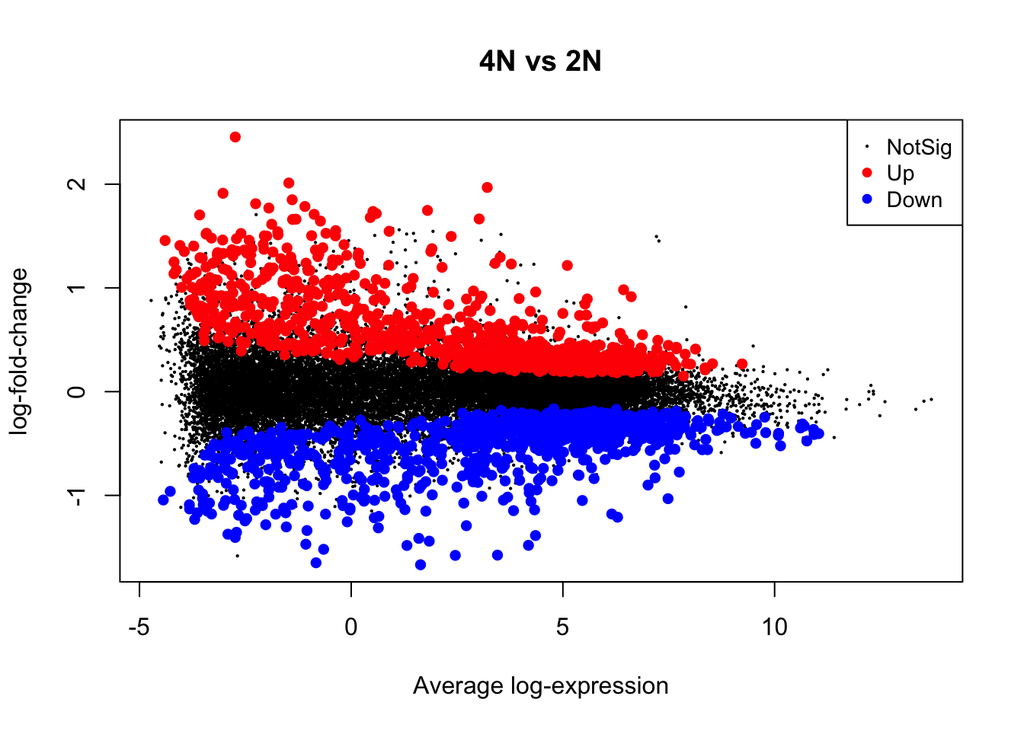

#### Gràfic de volcà

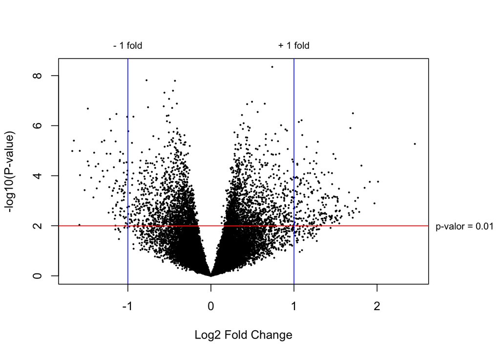

#### Heatmap dels gens més significatius

100 gens amb p-valor ajustat més baix:

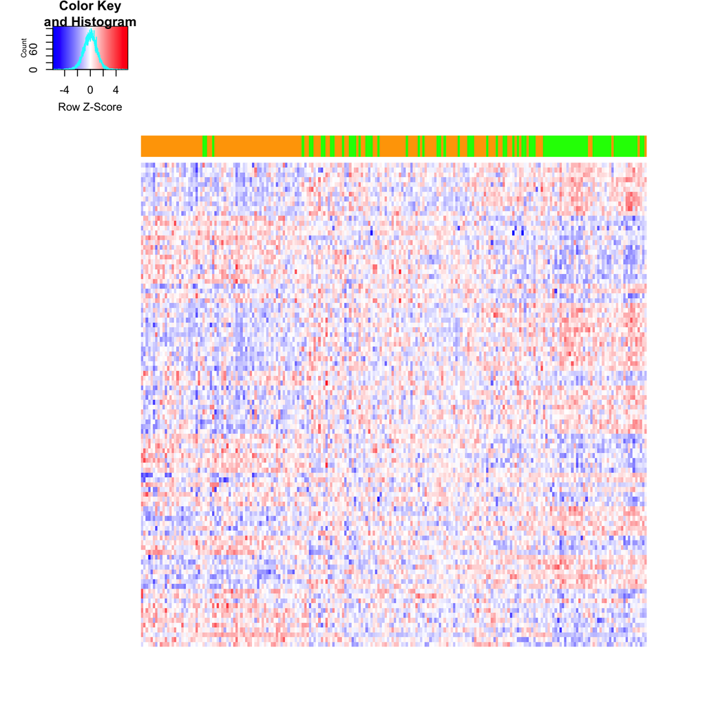

100 gens amb p-valor ajustat més baix després d’haver filtrat per aquells gens amb un logFC en valor absolut superior a 0.5 (aproximadament equivalent a FC superior a 1.4 o inferior a 0.7):

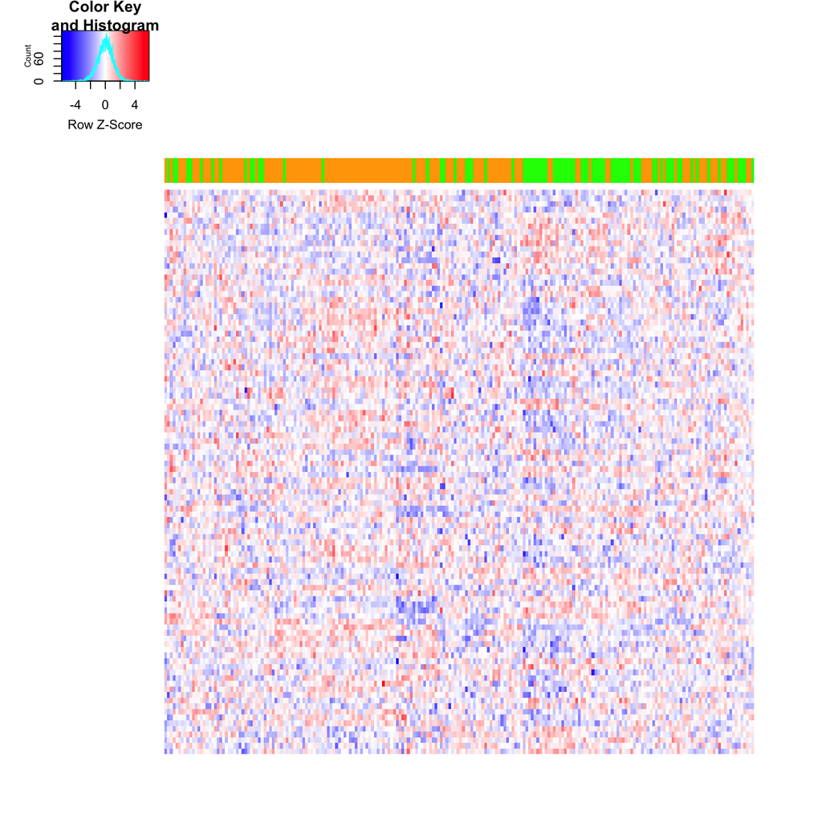

## Resultats de l’anàlisi d’enriquiment amb permutació de gene sets

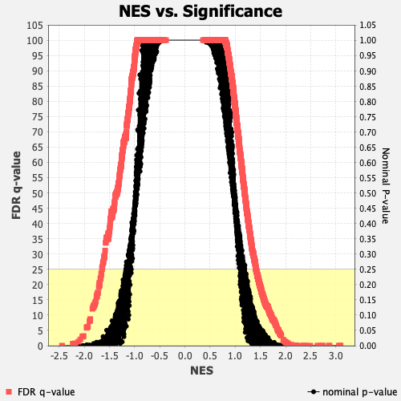

Termes enriquits al grup WGD

| NAME | FDR.q.val | NES |
| --- | --- | --- |
| GO_HUMORAL_IMMUNE_RESPONSE_MEDIATED_BY_CIRCULATING_IMMUNOGLOBULIN | 0.0000000 | 3.094779 |
| GO_PHAGOCYTOSIS_RECOGNITION | 0.0000000 | 3.091960 |
| GO_COMPLEMENT_ACTIVATION | 0.0000000 | 3.061447 |
| GO_MEMBRANE_INVAGINATION | 0.0000000 | 2.874363 |
| GO_B_CELL_RECEPTOR_SIGNALING_PATHWAY | 0.0000000 | 2.862103 |
| GO_REGULATION_OF_HUMORAL_IMMUNE_RESPONSE | 0.0000000 | 2.740765 |
| GO_B_CELL_MEDIATED_IMMUNITY | 0.0000000 | 2.722816 |
| GO_FC_RECEPTOR_MEDIATED_STIMULATORY_SIGNALING_PATHWAY | 0.0000000 | 2.681311 |
| GO_POSITIVE_REGULATION_OF_B_CELL_ACTIVATION | 0.0000000 | 2.635118 |
| GO_IMMUNOGLOBULIN_PRODUCTION | 0.0000000 | 2.491536 |
| GO_CELL_RECOGNITION | 0.0000000 | 2.422957 |
| GO_PHAGOCYTOSIS | 0.0000000 | 2.374462 |
| GO_REGULATION_OF_B_CELL_ACTIVATION | 0.0000000 | 2.363732 |
| GO_HUMORAL_IMMUNE_RESPONSE | 0.0000000 | 2.318014 |
| GO_FC_EPSILON_RECEPTOR_SIGNALING_PATHWAY | 0.0002977 | 2.212659 |
| GO_ADAPTIVE_IMMUNE_RESPONSE | 0.0002791 | 2.211509 |
| GO_B_CELL_ACTIVATION | 0.0002627 | 2.209525 |
| GO_LYMPHOCYTE_MEDIATED_IMMUNITY | 0.0004367 | 2.205791 |
| GO_ADAPTIVE_IMMUNE_RESPONSE_BASED_ON_SOMATIC_RECOMBINATION_OF_IMMUNE_RECEPTORS_BUILT_FROM_IMMUNOGLOBULIN_SUPERFAMILY_DOMAINS | 0.0004137 | 2.199425 |
| GO_PRODUCTION_OF_MOLECULAR_MEDIATOR_OF_IMMUNE_RESPONSE | 0.0003930 | 2.191382 |

Termes enriquits al grup no_WGD

| NAME | FDR.q.val | NES |
| --- | --- | --- |
| GO_NADH_DEHYDROGENASE_COMPLEX_ASSEMBLY | 0.0000000 | -2.445415 |
| GO_AXONEME_ASSEMBLY | 0.0065976 | -2.231263 |
| GO_ATP_SYNTHESIS_COUPLED_ELECTRON_TRANSPORT | 0.0065834 | -2.216989 |
| GO_OXIDATIVE_PHOSPHORYLATION | 0.0078120 | -2.179249 |
| GO_ATP_SYNTHESIS_COUPLED_PROTON_TRANSPORT | 0.0131598 | -2.118955 |
| GO_RESPIRATORY_ELECTRON_TRANSPORT_CHAIN | 0.0204776 | -2.081507 |
| GO_NUCLEOBASE_CONTAINING_SMALL_MOLECULE_INTERCONVERSION | 0.0299176 | -2.041158 |
| GO_MITOCHONDRIAL_ELECTRON_TRANSPORT_NADH_TO_UBIQUINONE | 0.0295917 | -2.031609 |
| GO_MITOCHONDRIAL_RESPIRATORY_CHAIN_COMPLEX_ASSEMBLY | 0.0315399 | -2.017375 |
| GO_RESPONSE_TO_COPPER_ION | 0.0604787 | -1.956370 |
| GO_PTERIDINE_CONTAINING_COMPOUND_BIOSYNTHETIC_PROCESS | 0.0582934 | -1.952112 |
| GO_AXONEMAL_DYNEIN_COMPLEX_ASSEMBLY | 0.0616734 | -1.939354 |
| GO_CELLULAR_RESPIRATION | 0.0621225 | -1.931191 |
| GO_REGULATION_OF_SYSTEMIC_ARTERIAL_BLOOD_PRESSURE_BY_HORMONE | 0.0801491 | -1.899519 |
| GO_MITOCHONDRIAL_TRANSLATIONAL_TERMINATION | 0.0870801 | -1.885600 |
| GO_TRANSLATIONAL_ELONGATION | 0.0823566 | -1.884681 |
| GO_CILIUM_MOVEMENT | 0.1206413 | -1.841051 |
| GO_MICROTUBULE_BUNDLE_FORMATION | 0.1251186 | -1.830775 |
| GO_PROTEASOMAL_UBIQUITIN_INDEPENDENT_PROTEIN_CATABOLIC_PROCESS | 0.1300864 | -1.821126 |
| GO_RESPONSE_TO_INTERFERON_BETA | 0.1315243 | -1.814840 |

## Anàlisis d’immunitat

### ESTIMATE

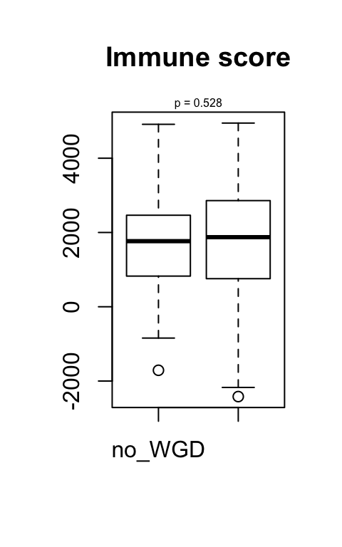

### Immunophenoscore

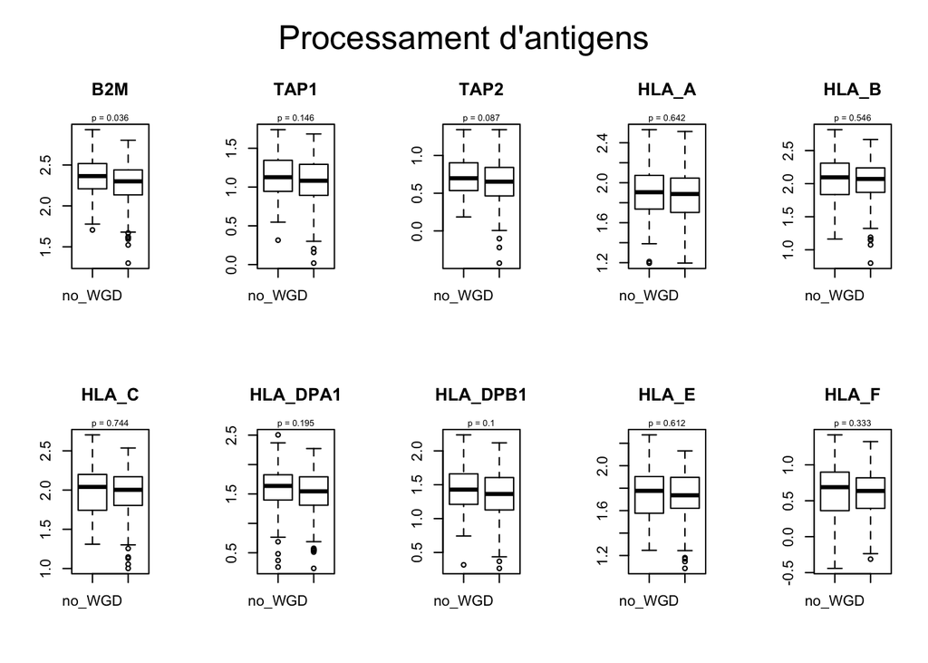

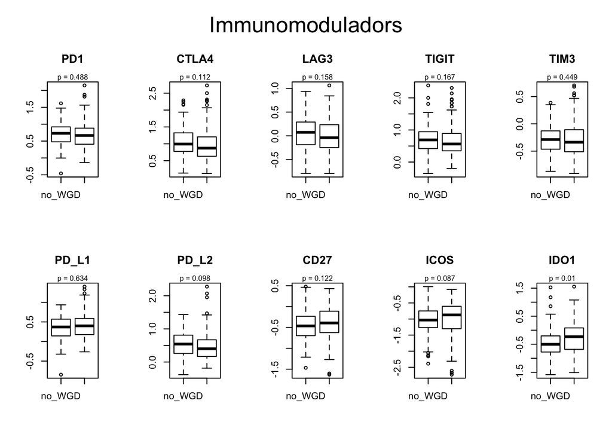

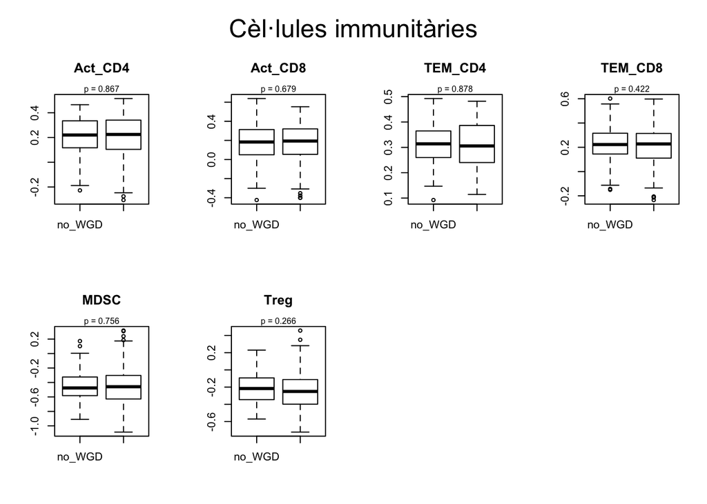

### Signatura 12-Chemokines

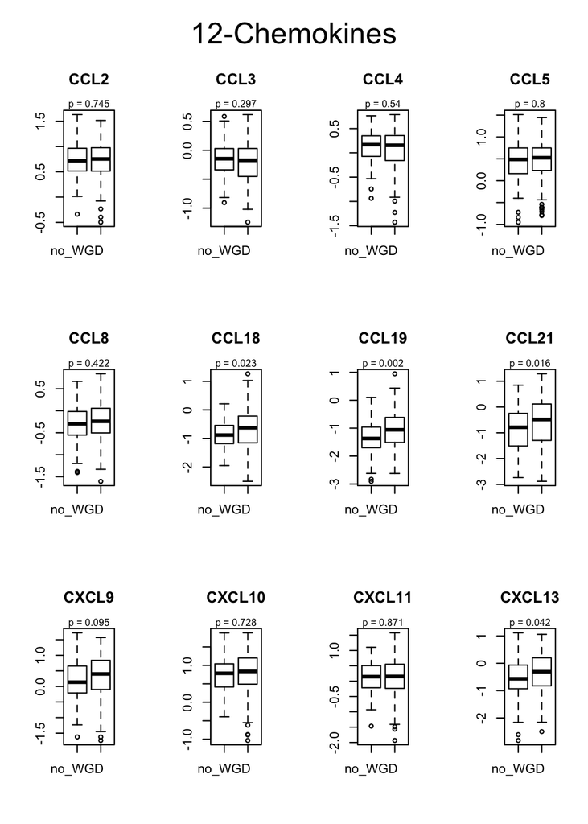